# Group_Research_Project_Smoking

11/18/2015

The cases of our dataset are various countries, with a few years per country. The variables include data on enforcement of law regarding smoking, namely smoking in public locations, funding for preventing smoking, and whether or not punishments were enforced in that country during the year.

Our main interest in this data is to examine the effect of state efforts to prevent smoking. Does increased spending on prevention efforts translate to a decrease in smoking? Does this phenomena vary by gender? Does it vary by region of the world? Why?

To answer this question, several things would be useful.

1. Visualizations

It is important to be able to visualize the relationships we are exploring. For example, a visualization of government spending as the explanatory variable and percentage of smokers as the response variable will be useful in visualizing a relationship. We will determine how appropriate a linear model can be for fitting this relationship.

2. Hypothesis tests

It is equally important to test if differences in mean smoking rates between genders are statistically significant. We can do this through a differences in mean tests, ie. a two sample t test. We will most likely use a 95% confidence interval because that is the standard for significance.

Loading libraries

```r
library(ggplot2)
library(dplyr)
library(stringr)
set.seed(1124)
```

Loading the first data set and renaming columns into more intuitive names:

Loading the first data set and renaming columns into more intuitive names

```r
data1 <- read.csv("data (1).csv", stringsAsFactors=FALSE)

colnames(data1) = c("Country",
                    "Year",
                    "smokefreespots",
                    "finesforviolations",
                    "finesongovernment",
                    "finesonpatron",
                    "fundsforenforcement",
                    "complaints",
                    "subnationallegislation",
                    "subnationalbans")

data1 <- data1 %>%
  mutate(smokefreespots = as.integer(smokefreespots))
```

Loading the second dataset and renaming the columns to be easier to access:

Loading the second dataset and renaming the columns to be easier to access

```r
data2 <- read.csv("data-text.csv", stringsAsFactors=FALSE)
#head(data2)
#str(data2)
data.text <- data2 %>%
  mutate(demo = ifelse(Indicator == "Prevalence of current tobacco use among adolescents aged 13-15 years", "teen", ifelse(Indicator == "Prevalence of smoking any tobacco product among persons aged >= 15 years", "adult", Indicator)))
```

Merging the two datasets into one:

```r
smoking <- merge(data1, data.text, by = intersect(names(data1), names(data.text)))
smoking <- smoking %>%
  mutate(demo = ifelse(Indicator == "Prevalence of current tobacco use among adolescents aged 13-15 years", "teen", ifelse(Indicator == "Prevalence of smoking any tobacco product among persons aged >= 15 years", "adult", Indicator)))
```

```r
str(smoking)
```

```
## 'data.frame':    650 obs. of  20 variables:
##  $ Country               : chr  "Albania" "Albania" "Albania" "Albania" ...
##  $ Year                  : int  2010 2010 2012 2012 2010 2010 2012 2012 2007 2007 ...
##  $ smokefreespots        : int  8 8 8 8 0 0 5 5 0 0 ...
##  $ finesforviolations    : chr  "No" "No" "No" "No" ...
##  $ finesongovernment     : chr  "Not applicable" "Not applicable" "Not applicable" "Not applicable" ...
##  $ finesonpatron         : chr  "Not applicable" "Not applicable" "Not applicable" "Not applicable" ...
##  $ fundsforenforcement   : chr  "No" "No" "No" "No" ...
##  $ complaints            : chr  "No" "No" "No" "No" ...
##  $ subnationallegislation: chr  "No" "No" "No" "No" ...
##  $ subnationalbans       : chr  "Not applicable" "Not applicable" "Not applicable" "Not applicable" ...
##  $ Indicator             : chr  "Prevalence of smoking any tobacco product among persons aged >= 15 years" "Prevalence of smoking any tobacco product among persons aged >= 15 years" "Prevalence of smoking any tobacco product among persons aged >= 15 years" "Prevalence of smoking any tobacco produ…
##  $ PUBLISH.STATES        : chr  "Published" "Published" "Published" "Published" ...
##  $ WHO.region            : chr  "Europe" "Europe" "Europe" "Europe" ...
##  $ Sex                   : chr  "Male" "Female" "Male" "Female" ...
##  $ Display.Value         : chr  "53.1 [42.8-65.4]" "8.7 [6.4-11.5]" "52.1 [40.3-64.9]" "8.2 [5.7-10.8]" ...
##  $ Numeric               : num  53.1 8.7 52.1 8.2 39.2 28.8 28.4 38.5 26.1 29.7 ...
##  $ Low                   : num  42.8 6.4 40.3 5.7 30.2 20.9 18.8 28.6 NA NA ...
##  $ High                  : num  65.4 11.5 64.9 10.8 51 38.1 36.7 50.1 NA NA ...
##  $ Comments              : chr  "" "" "" "" ...
##  $ demo                  : chr  "adult" "adult" "adult" "adult" ...
```

```r
head(smoking)
```

```
##   Country Year smokefreespots finesforviolations finesongovernment
## 1 Albania 2010              8                 No    Not applicable
## 2 Albania 2010              8                 No    Not applicable
## 3 Albania 2012              8                 No    Not applicable
## 4 Albania 2012              8                 No    Not applicable
## 5 Andorra 2010              0                Yes                No
## 6 Andorra 2010              0                Yes                No
##    finesonpatron fundsforenforcement complaints subnationallegislation
## 1 Not applicable                  No         No                     No
## 2 Not applicable                  No         No                     No
## 3 Not applicable                  No         No                     No
## 4 Not applicable                  No         No                     No
## 5            Yes                  No         No                     No
## 6            Yes                  No         No                     No
##   subnationalbans
```

[output cut: 27 more lines]

```r
  sidebarLayout(
    sidebarPanel(

      selectInput("var1",
                  "Explanatory Variable",
                  choices = c("carat",
                              "depth",
                              "price",
                              "x",
                              "y",
                              "z",
                              "table")),

      selectInput("var2",
                  "Numeric Variable",
                  choices = c("carat",
                              "depth",
                              "price",
                              "x",
                              "y",
                              "z",
                              "table")),

      selectInput("color",
                  "Categorical Variable (color)",
                  choices = c("cut",
                              "clarity",
                              "color")),

      hr()





      ),







    mainPanel(

      plotOutput('popPlot')
    )

    )

output$popPlot <- renderPlot({

    pop_name1 = switch(input$var1,
                      carat = "Carats",
                      depth  = "Depth",
                      table = "Table",
                      price = "Price",
                      x = "X",
                      y = "Y",
                      z = "Z")

    pop_name2 = switch(input$var1,
                       carat = "Carats",
                       depth  = "Depth",
                       table = "Table",
                       price = "Price",
                       x = "X",
                       y = "Y",
                       z = "Z")


    ggplot(data = diamonds, aes_string(x = input$var1, y = input$var2, color = input$color)) +
      geom_point(position = "jitter") +
      ggtitle(pop_name1)

  })
```

### 1. Do allocating funds to enforce smoking laws make a real difference in

### smoking rates? Does it vary by gender?

The first step in answering this question is to make a visualization of the variables in question, namely “fundsforenforcement”, “Numeric”, and “Sex”.

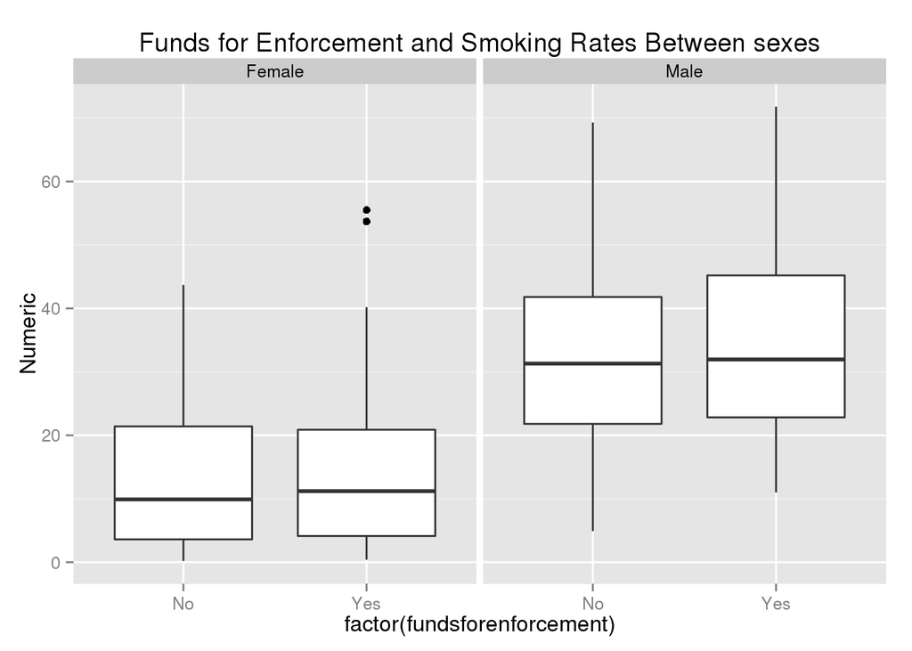

```r
ggplot(data = smoking, aes(x = factor(fundsforenforcement), y = Numeric))+
  geom_boxplot()+
  facet_wrap("Sex")+
  ggtitle("Funds for Enforcement and Smoking Rates Between sexes")
```

We can make some initial observations from this graph. First, for both sexes, it appears that if the government allocates funds to enforce smoking laws, there are actually a greater number of people who smoke. One possible explanation for this is that in countries where funds to prevent smoking are necessary, there is already a high number of people who smoke.

Another observation we get from this plot is that smoking is much more prevalent among males than females.

The first hypothesis test we can do to test for significance is if there is a true difference in smoking rates for countries who allocate funds to prevent it or not.

```r
funds_yes <- smoking %>%
  filter(fundsforenforcement == "Yes")
funds_no <- smoking %>%
  filter(fundsforenforcement == "No")
funds_boot <- data.frame(yes = rep(NA, 15000), no = rep(NA, 15000))
for(i in 1:15000){
  s <- sample(funds_yes$Numeric, length(funds_yes$Numeric), replace = TRUE)
  funds_boot$yes[i] <- mean(s)
  s <- sample(funds_no$Numeric, length(funds_no$Numeric), replace = TRUE)
  funds_boot$no[i] <- mean(s)
}
```

The following t test is a two sided t test to test if the sample data, not the bootstrapped data, are significantly different.

```r
t.test(funds_yes$Numeric, funds_no$Numeric, null = 0, alternative = "two.sided")
```

```
##
##  Welch Two Sample t-test
##
## data:  funds_yes$Numeric and funds_no$Numeric
## t = 0.67068, df = 269.32, p-value = 0.503
## alternative hypothesis: true difference in means is not equal to 0
## 95 percent confidence interval:
##  -1.871860  3.806066
## sample estimates:
## mean of x mean of y
##  23.56463  22.59753
```

```r
se <- sd(funds_boot$yes - funds_boot$no)
p_hat <- mean(funds_yes$Numeric) - mean(funds_no$Numeric)
(boot_int = round(p_hat + c(-1,1) * 1.96 * se, 4))
```

```
## [1] -1.8238  3.7580
```

```r
t.test(funds_boot$yes, funds_boot$no, alternative = "two.sided")
```

[output not shown]

We get a p value of 0.503, which represents the probability of getting the observed difference or more extreme, so in this case a difference of the means down to 0. The p value is relatively large, so we fail to reject the null hypothesis. Based solely on the sample data, there is not a significant difference in smoking rates between countries that provide funds for enforcement and those that do not.

The next question to answer from these variables is whether or not there is a statistically significant difference between smoking rates for males and females.

```r
smoking_male <- smoking %>%
  filter(Sex == "Male")
smoking_female <- smoking %>%
  filter(Sex == "Female")
```

```r
sex_boot <- data.frame(male = rep(NA, 15000), female = rep(NA, 15000))
for(i in 1:15000){
  s <- sample(smoking_male$Numeric, length(smoking_male$Numeric), replace = TRUE)
  sex_boot$male[i] <- mean(s)
  s <- sample(smoking_female$Numeric, length(smoking_female$Numeric), replace = TRUE)
  sex_boot$female[i] <- mean(s)
}
```

Now the t test with the sample data

```r
t.test(smoking_male$Numeric, smoking_female$Numeric, alternative = "two.sided")
```

```
##
##  Welch Two Sample t-test
##
## data:  smoking_male$Numeric and smoking_female$Numeric
## t = 20.041, df = 619.05, p-value < 2.2e-16
## alternative hypothesis: true difference in means is not equal to 0
## 95 percent confidence interval:
##  17.37690 21.15235
## sample estimates:
## mean of x mean of y
##  32.53313  13.26850
```

Calculating the confidence interval using bootstrapped data

```r
p_hat <- mean(smoking_male$Numeric) - mean(smoking_female$Numeric)
se <- sd(sex_boot$male - sex_boot$female)
(boot_int <- round(p_hat + c(-1,1) * 1.96 * se, 4))
```

```
## [1] 17.3639 21.1653
```

```r
t.test(sex_boot$male, sex_boot$female, alternative = "two.sided")
```

[output not shown]

Therefore, whatever policy the government makes to prevent smoking should be more targeted towards males because they are where the most smoking comes from.

### Does the percentage of teen smokers differ from the number of adult smokers in various regions?

Let’s visualize the relationship between the variables

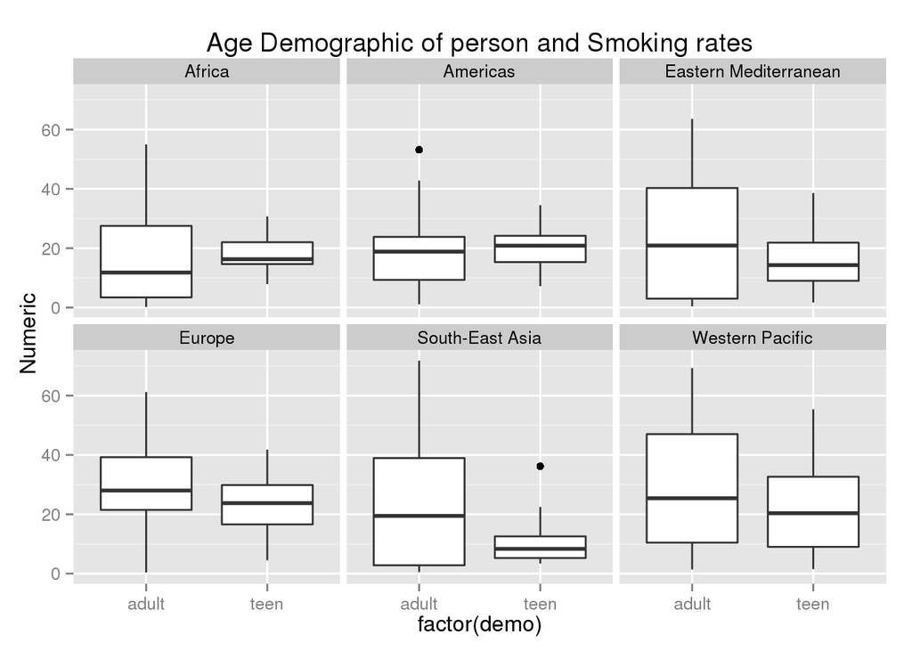

```r
ggplot(data = smoking, aes(x = factor(demo), y = Numeric))+
  geom_boxplot()+
  facet_wrap("WHO.region")+
  ggtitle("Age Demographic of person and Smoking rates")
```

Based solely on that plot, we can see that the only regions in which teen smokers is greater than adult smokers is in Africa and the Americas.

We can also make a summary table of the values to get a more quantitative description of the data

```r
summ_region_teen <- smoking %>%
  filter(demo == "teen")%>%
  group_by(WHO.region)%>%
  summarise(mean = mean(Numeric), sd = sd(Numeric), IQR = IQR(Numeric))
summ_region_teen
```

```
## Source: local data frame [6 x 4]
##
##              WHO.region     mean        sd    IQR
## 1                Africa 17.90000  6.338454  7.375
## 2              Americas 19.68667  6.738194  8.850
## 3 Eastern Mediterranean 16.28125  9.840090 12.850
## 4                Europe 23.29615  9.974066 13.250
## 5       South-East Asia 11.15000  9.475663  7.300
## 6       Western Pacific 23.20909 15.910341 23.625
```

```r
summ_region_adult <- smoking %>%
  filter(demo == "adult")%>%
  group_by(WHO.region)%>%
  summarise(mean = mean(Numeric), sd = sd(Numeric), IQR = IQR(Numeric))
summ_region_adult
```

```
## Source: local data frame [6 x 4]
##
##              WHO.region     mean       sd    IQR
## 1                Africa 15.93070 14.45760 24.100
## 2              Americas 18.97436 12.17236 14.500
## 3 Eastern Mediterranean 21.76667 19.04140 37.300
## 4                Europe 29.57880 13.57427 17.775
## 5       South-East Asia 22.91071 21.17429 36.150
## 6       Western Pacific 28.26667 20.30129 36.575
```

One interesting thing to explore is if the difference between teens and adults for the Americas, namely if this relationship is signficant.

```r
smoking_americas_teens <- smoking %>%
  filter(Indicator == "Prevalence of current tobacco use among adolescents aged 13-15 years" & WHO.region == "Americas")

smoking_americas_adults <- smoking%>%
  filter(Indicator == "Prevalence of smoking any tobacco product among persons aged >= 15 years" & WHO.region == "Americas")

smoking_africa_teens <- smoking %>%
  filter(Indicator == "Prevalence of current tobacco use among adolescents aged 13-15 years" & WHO.region == "Africa")

smoking_africa_adults <- smoking%>%
  filter(Indicator == "Prevalence of smoking any tobacco product among persons aged >= 15 years" & WHO.region == "Africa")
```

We can now do a hypothesis test for the difference between teen and adult smoking rates.

```r
smoking_diff <- data.frame(am_diff = rep(NA, length(smoking_americas_teens$Numeric)), af_diff = rep(NA, length(smoking_americas_teens$Numeric)))
for (i in 1:length(smoking_americas_teens$Numeric)){
  s = sample(smoking_americas_teens$Numeric, length(smoking_americas_teens$Numeric), replace = TRUE)
  s1 = sample(smoking_americas_adults$Numeric, length(smoking_americas_teens$Numeric), replace = TRUE)
  m = mean(s - s1)
  smoking_diff$am_diff[i] <- m
  s2 = sample(smoking_africa_teens$Numeric, length(smoking_africa_teens$Numeric), replace = TRUE)
  s3 = sample(smoking_africa_adults$Numeric, length(smoking_africa_teens$Numeric), replace = TRUE)
  m1 = mean(s2 - s3)
  smoking_diff$af_diff[i] <- m1

}
```

To test if the difference in means of the differences of teen and adult smoking rates are different in Africa as compared to America, we can do a paired t test on means of the differences from samples of the data.

```r
t.test(smoking_diff$am_diff, smoking_diff$af_diff, paired = TRUE)
```

```
##
##  Paired t-test
##
## data:  smoking_diff$am_diff and smoking_diff$af_diff
## t = -2.9892, df = 29, p-value = 0.005649
## alternative hypothesis: true difference in means is not equal to 0
## 95 percent confidence interval:
##  -3.862269 -0.724203
## sample estimates:
## mean of the differences
##               -2.293236
```

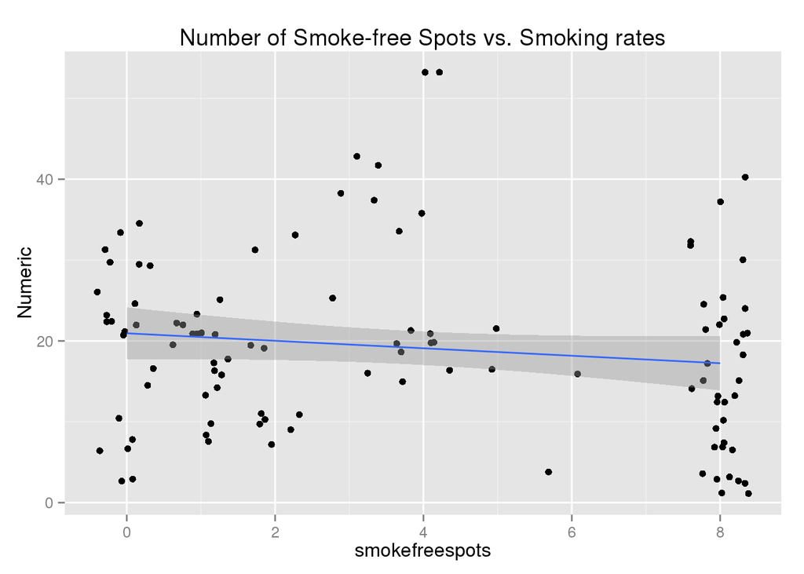

```r
smoking2 <- smoking %>%
  filter(WHO.region == "Americas")
ggplot(data = smoking2, aes(x = smokefreespots, y = Numeric))+
  geom_point(position= "jitter")+
  ggtitle("Number of Smoke-free Spots vs. Smoking rates")+
stat_smooth(method = "lm", fullrange = TRUE)
```